# Divvy Bike Share 2024 Analysis

Dmytro Khavrel

# 1 🚲 Introduction: About Divvy

Divvy is Chicago’s official bike share system, launched in 2013 and operated by **Lyft** in partnership with the **Chicago Department of Transportation (CDOT)**. It has grown into one of the largest bike share programs in North America, with:

- Over **800 docking stations** across Chicago and nearby suburbs,
- A fleet of **traditional pedal bikes** and **electric Divvy eBikes**,
- Options for **casual riders** (pay-as-you-go) and **annual members**.

Divvy continues expanding its network and electrified fleet, while aiming to convert more casual users into long-term members. This analysis uses full-year trip data from 2024 to explore ridership trends and support Divvy’s business goals.

## 1.1 🎯 Project Goals

This project answers key business questions:

1. **How do annual members and casual riders use Divvy bikes differently?**
2. **Why would casual riders buy annual memberships?**
3. **How can Divvy use digital media to influence casual riders to become members?**

We will use R to process, clean, analyze, and visualize real trip data, leading to insights and marketing recommendations.

# 2 📥 Load & Prepare Data

```r
#setwd("Divvy Trips 2024")
months <- sprintf("%02d", 1:12)
files <- paste0("2024", months, "-divvy-tripdata.csv")

divvy_2024 <- files %>% map_df(read_csv)

# Ride duration
divvy_2024$ride_length <- difftime(divvy_2024$ended_at, divvy_2024$started_at)
divvy_2024$ride_length <- as.numeric(divvy_2024$ride_length)
```

```r
divvy_2024_clean <- divvy_2024 %>%
  distinct(ride_id, .keep_all = TRUE) %>%
  drop_na(ride_id, started_at, ended_at, member_casual, rideable_type,
          start_station_name, end_station_name, start_lat, start_lng, end_lat, end_lng) %>%
  mutate(across(c(start_station_name, end_station_name), str_trim)) %>%
  filter(
    ride_length > 0,
    start_station_name != "HQ QR",
    between(start_lat, 40.73, 42.67),
    between(end_lat, 40.73, 42.67),
    between(start_lng, -88.94, -86.93),
    between(end_lng, -88.94, -86.93),
    nchar(start_station_name) > 1,
    nchar(end_station_name) > 1
  )

# Add day of the week
divvy_2024_clean <- divvy_2024_clean %>%
  mutate(date = as.Date(started_at),
         day_of_week = format(date, "%A"))
```

# 3 📊 Descriptive Statistics

```r
summary(divvy_2024_clean$ride_length)
```

```
##      Min.   1st Qu.    Median      Mean   3rd Qu.      Max.
##     0.103   350.000   608.139   999.332  1093.000 90562.000
```

## 3.1 🚲 Average Ride Length by Rider Type

```r
divvy_2024_clean %>%
  group_by(member_casual) %>%
  summarise(
    mean_duration = mean(ride_length),
    median_duration = median(ride_length),
    max_duration = max(ride_length),
    min_duration = min(ride_length)
  )
```

| member_casual | mean_duration | median_duration | max_duration | min_duration |
| --- | --- | --- | --- | --- |
| casual | 1442.7120 | 804.6535 | 90562 | 0.1030002 |
| member | 748.2288 | 529.0000 | 89859 | 0.1389999 |

# 4 📈 Ride Patterns

## 4.1 🗓️ Weekly Ridership Count

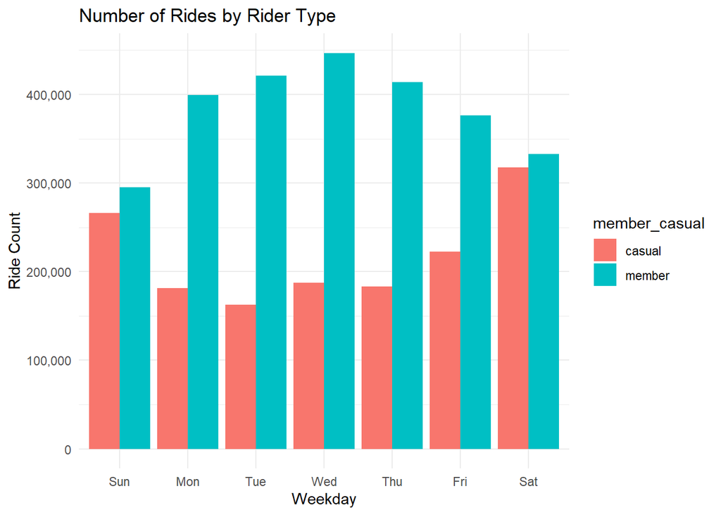

```r
divvy_2024_clean %>%
  mutate(weekday = wday(started_at, label = TRUE)) %>%
  group_by(member_casual, weekday) %>%
  summarise(number_of_rides = n(), .groups = "drop") %>%
  ggplot(aes(x = weekday, y = number_of_rides, fill = member_casual)) +
  geom_col(position = "dodge") +
  scale_y_continuous(labels = label_comma()) +
  labs(title = "Number of Rides by Rider Type", y = "Ride Count", x = "Weekday") +
  theme_minimal()
```

## 4.2 ⏱️ Average Duration per Day

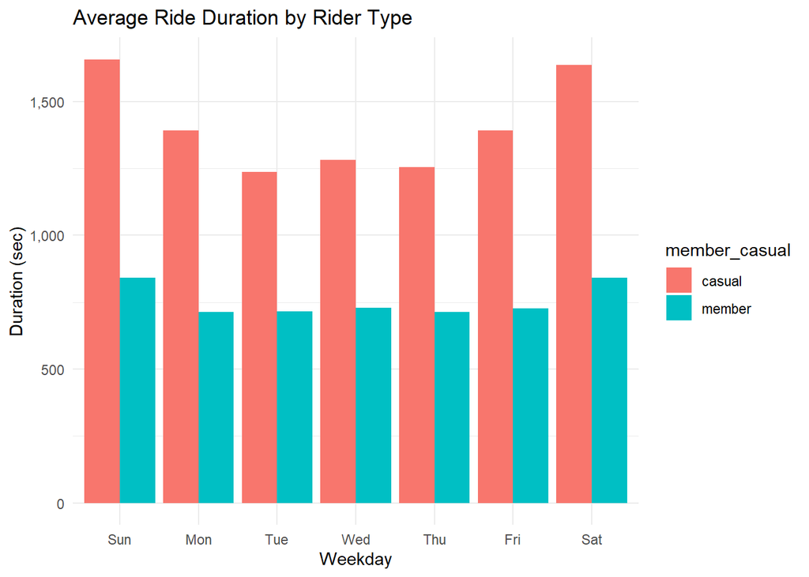

```r
divvy_2024_clean %>%
  mutate(weekday = wday(started_at, label = TRUE)) %>%
  group_by(member_casual, weekday) %>%
  summarise(average_duration = mean(ride_length), .groups = "drop") %>%
  ggplot(aes(x = weekday, y = average_duration, fill = member_casual)) +
  geom_col(position = "dodge") +
  scale_y_continuous(labels = label_comma()) +
  labs(title = "Average Ride Duration by Rider Type", y = "Duration (sec)", x = "Weekday") +
  theme_minimal()
```

## 4.3 📍 Ride Start Heat Map

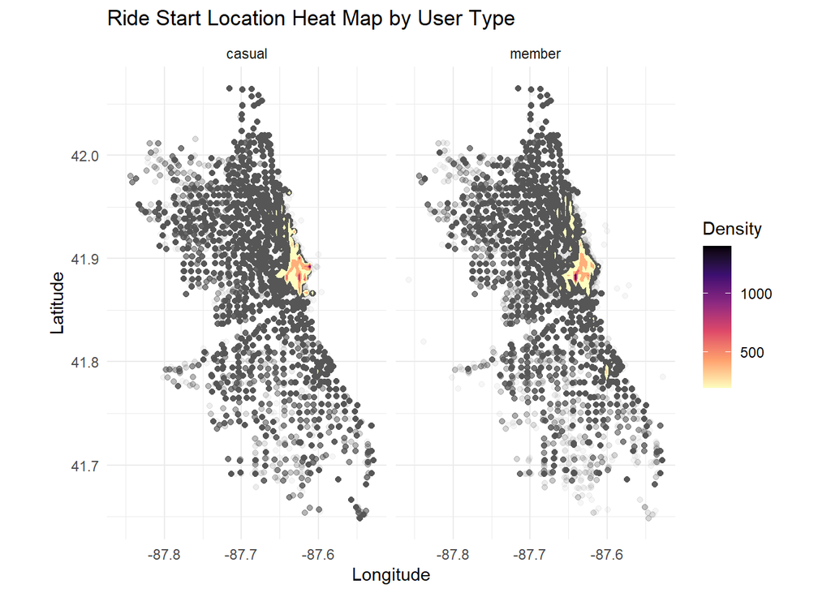

```r
divvy_2024_clean %>%
  ggplot(aes(x = start_lng, y = start_lat)) +
  geom_point(alpha = 0.05, color = "grey30") +
  stat_density_2d(aes(fill = after_stat(level)), geom = "polygon", color = NA, contour = TRUE) +
  scale_fill_viridis_c(option = "magma", direction = -1) +
  coord_quickmap() +
  facet_wrap(~ member_casual) +
  labs(
    title = "Ride Start Location Heat Map by User Type",
    x = "Longitude",
    y = "Latitude",
    fill = "Density"
  ) +
  theme_minimal()
```

## 4.4 📍 Ride End Heat Map

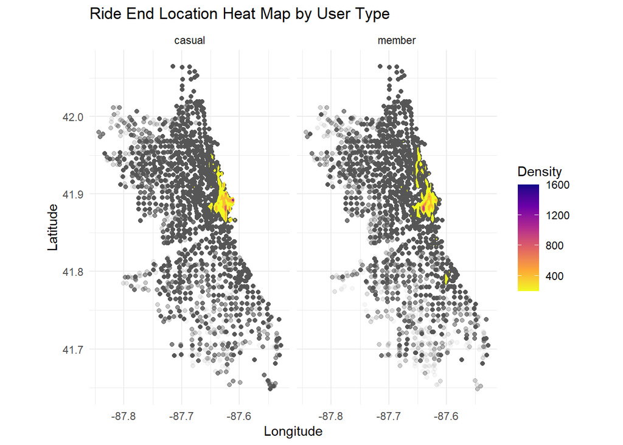

```r
divvy_2024_clean %>%
  ggplot(aes(x = end_lng, y = end_lat)) +
  geom_point(alpha = 0.05, color = "grey30") +
  stat_density_2d(aes(fill = after_stat(level)), geom = "polygon", color = NA, contour = TRUE) +
  scale_fill_viridis_c(option = "plasma", direction = -1) +
  coord_quickmap() +
  facet_wrap(~ member_casual) +
  labs(
    title = "Ride End Location Heat Map by User Type",
    x = "Longitude",
    y = "Latitude",
    fill = "Density"
  ) +
  theme_minimal()
```

# 5 📤 Export Clean Data

```r
write.csv(divvy_2024_clean, "divvy_2024_member_vs_casual.csv", row.names = FALSE)
```

# 6 🔍 Key Insights

## 6.1 ✅ How do annual members and casual riders differ?

Casual riders tend to:

- Ride more on weekends.
- Take longer trips.
- Use bikes for recreation.

Annual members are more likely to:

- Ride during weekdays.
- Take shorter trips.
- Use bikes for commuting or errands.

## 6.2 💡 Why might casual riders convert to membership?

- Regular weekend riders could save money by switching to an annual plan.
- Convenience: easier access, no per-ride hassle.
- Better value for frequent short rides.

## 6.3 📣 Digital Marketing Strategy Suggestions

- Targeted ads on weekends showing savings based on their usage.
- Promote features like unlock speed and exclusive stations.
- Offer trial discounts during peak casual riding months (e.g., summer).

## 6.4 📌 Conclusion

Divvy can grow its annual membership base by:

- Understanding behavioral patterns,
- Personalizing offers based on usage,
- Making value propositions clear through data-driven digital media.